# Week 7

## Skills

This week we will target the following skills:

1. Understanding of simple R commands
2. Basic navigation of RStudio interface
3. Using functions in R
4. Writing functions in R
5. Using scripts in R/RStudio
6. Install and load packages
7. Use the `help()` function in R to find information
8. Combine the skills learnt so far

## Applied skills, exercises, resources.

All the references for this week link to “Hands-On Programming with R”, by Garrett Grolemund. You can get a physical copy of the book if you wish, but the standard and better way to access it is the free-to-use website: [https://RStudio-education.github.io/hopr/index.html](https://rstudio-education.github.io/hopr/index.html). The required readings for this weeks are:

- Section 2.1
- Section 2.2
- Section 2.3
- Section 2.4
- Section 2.5
- Section 2.6
- Section 3.1
- Section 3.2

The following is a mixture of exercises and exploratory activities that you have to go through. The right approach is to first read the sources (e.g., section 2.1, 2.2), and then to go through each block in this document. Please do not advance unless you are confident you are mastering the content.

**Discosure:** an important part of the R world is Tidyverse. You could have seen it in a previous unit, and surely will do in future units. In this unit, we will explicitly avoid Tidyverse, as our focus is on basic/core R. Should we use anything from the Tidyverse world, as for example functions in the package `ggplot2`, we will do it as an example only.

### 1. Understanding of simple R commands [Section 2.1, 2.2]

*Learning outcomes:*

- *Execute operations*
- *Create an object*
- *Change value of objects*
- *Create a numeric vector*
- *Create a matrix*
- *Element-wise execution*
- *Inner multiplication, outer multiplication*
- *Naming rules in R*

Instructions:

- Creating objects and assigning values in R: objects are assigned values using `<-` , an arrow formed out of < and -. An equal sign, `=`, can also be used. For example, the following command assigns the value 1 to the object x.

```r
x <- 1
```

- Exploratory activity: type the following commands, followed by enter, and observe the output. In the following there are different level of complexity. Can you explain what is happening with each command?

```r
1+1
```

```
## [1] 2
```

```r
2*24
```

```
## [1] 48
```

```r
2^4
```

```
## [1] 16
```

```r
log(10)
```

```
## [1] 2.302585
```

```r
log10(10)
```

```
## [1] 1
```

```r
exp(3)
```

```
## [1] 20.08554
```

```r
x <- 2
x
```

```
## [1] 2
```

```r
x+3
```

```
## [1] 5
```

```r
x <- x+3
x
```

```
## [1] 5
```

```r
1:10
```

```
##  [1]  1  2  3  4  5  6  7  8  9 10
```

```r
a <- 1:10
a
```

```
##  [1]  1  2  3  4  5  6  7  8  9 10
```

```r
a[3]
```

```
## [1] 3
```

```r
a <- a+5
a
```

```
##  [1]  6  7  8  9 10 11 12 13 14 15
```

```r
a * a
```

```
##  [1]  36  49  64  81 100 121 144 169 196 225
```

```r
a %*% a
```

```
##      [,1]
## [1,] 1185
```

```r
a %o% a
```

```
##       [,1] [,2] [,3] [,4] [,5] [,6] [,7] [,8] [,9] [,10]
##  [1,]   36   42   48   54   60   66   72   78   84    90
##  [2,]   42   49   56   63   70   77   84   91   98   105
##  [3,]   48   56   64   72   80   88   96  104  112   120
##  [4,]   54   63   72   81   90   99  108  117  126   135
##  [5,]   60   70   80   90  100  110  120  130  140   150
##  [6,]   66   77   88   99  110  121  132  143  154   165
##  [7,]   72   84   96  108  120  132  144  156  168   180
##  [8,]   78   91  104  117  130  143  156  169  182   195
##  [9,]   84   98  112  126  140  154  168  182  196   210
## [10,]   90  105  120  135  150  165  180  195  210   225
```

```r
matrix(data=1:50, nrow=5, ncol=10)
```

```
##      [,1] [,2] [,3] [,4] [,5] [,6] [,7] [,8] [,9] [,10]
## [1,]    1    6   11   16   21   26   31   36   41    46
## [2,]    2    7   12   17   22   27   32   37   42    47
## [3,]    3    8   13   18   23   28   33   38   43    48
## [4,]    4    9   14   19   24   29   34   39   44    49
## [5,]    5   10   15   20   25   30   35   40   45    50
```

- Naming objects: try experimenting with different names. Are names case sensitive? What characters can we use in names? Discuss with peers and the instructor strategies/patterns to name your objects.

### 2. Basic navigation of RStudio interface [Section 2.1, 2.2]

*Learning outcomes:*

- *Learn where to write commands, and where to find objects*

Instructions:

- Explore panes in RStudio.
  - In which pane can you write commands?
  - In which pane can you explore objects?
  - What other panes can you find in RStudio? Can you guess what they are used for?
- Change the panes layout.
  - In Tools/Global Options/Pane Layout, you can decide the layout of panes in RStudio. Experiment with it. Going on in this unit, you could decide that there is a layout that works better for you than the default one.

### 3. Using functions in R [Section 2.3]

*Learning outcomes:*

- *Understand the anatomy of a function, ie the name and the argument/s*
- *Use the important functions round() and mean()*
- *Can we apply a function to the result of a function?*

Instructions:

- Type and reflect on the results of the following commands:

```r
round(3.14159)
```

```
## [1] 3
```

```r
round(3.14159, 2)
```

```
## [1] 3.14
```

```r
round(x=3.14159, digits=2)
```

```
## [1] 3.14
```

```r
x <- 1:10
mean(x)
```

```
## [1] 5.5
```

```r
round(mean(x))
```

```
## [1] 6
```

```r
round(mean(x), digits=0)
```

```
## [1] 6
```

```r
round(mean(x), digits=2)
```

```
## [1] 5.5
```

- In the last two commands above, are the `digits=0` and `digits=2` arguments being used by the function `round()` or `mean()`?

### 4. Writing functions in R [Section 2.4, 2.5]

*Learning outcomes:*

- *Write your first function*

Instructions:

- Type the code below and reflect on the results.

```r
my_func <- function(x){
    x <- x+2
    mean(x)
}
my_func(1:10)
```

```
## [1] 7.5
```

```r
my_func(1:5)
```

```
## [1] 5
```

- Write a function that takes in input 2 numbers and sum them.
- What happens if we run the function with strings in input?

### 5. Using scripts in R/RStudio [Section 2.6]

*Learning outcomes:*

- *Create a script and write a few commands in it.*
- *Save a script.*
- *Execute commands from scripts.*

Instructions:

- Create a blank script.
- Write a function in a script and a few commands that execute it (as we just did in part 4).
- Save the script.
- Execute the function and the commands.

### 6. Install and load packages [Section 3.1]

*Learning outcomes:*

- *Find out when and why a function is not available in R*
- *If appropriate, install a package*
- *If appropriate, load a package*

Not all commands/functions are readily available in R. Sometimes functions are part of so-called packages. We need to load them in the environment before being able to use them. If the package is not available, we need to install it.

Instructions:

- Run and evaluate the output of the following commands:

```r
qplot()
```

```
## Error in qplot(): could not find function "qplot"
```

```r
install.packages("ggplot2")
library("ggplot2")
qplot
```

[output not shown]

[output cut: 37 more lines]

[output not shown]

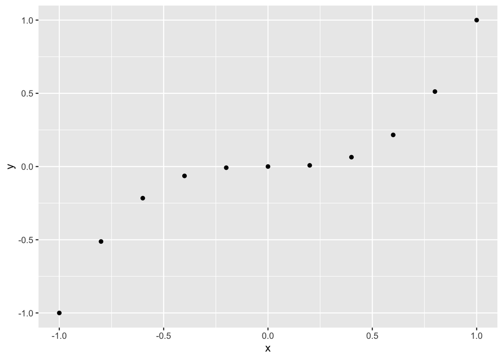

```r
x <- c(-1, -0.8, -0.6, -0.4, -0.2, 0, 0.2, 0.4, 0.6, 0.8, 1)
y <- x^3
qplot(x, y)
```

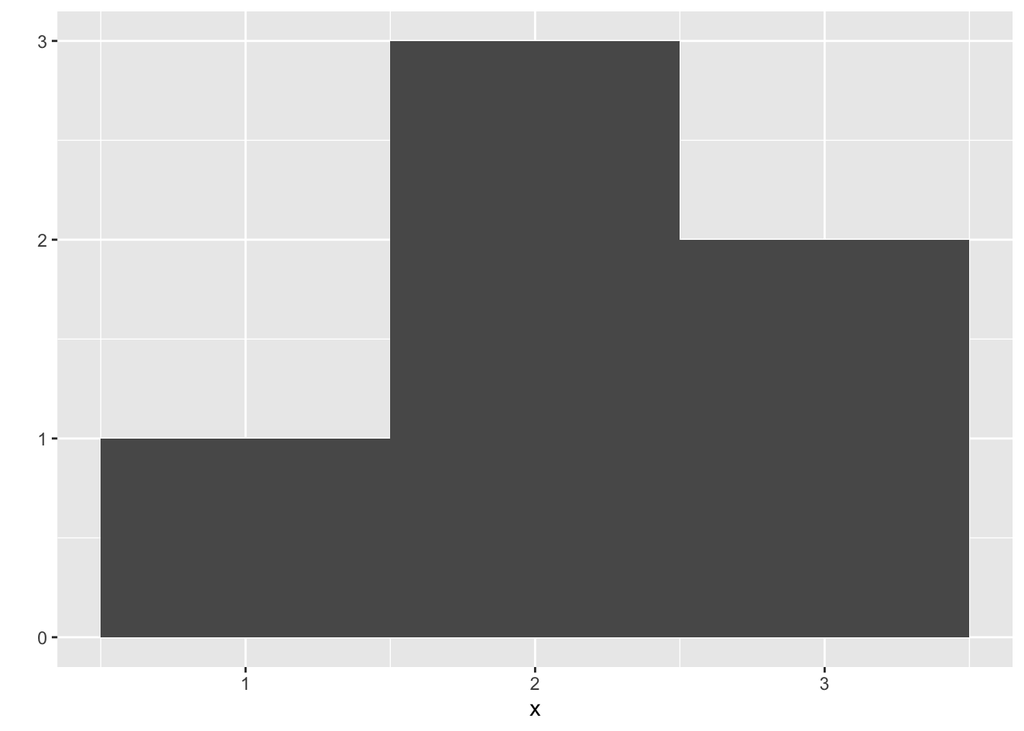

```r
x <- c(1, 2, 2, 2, 3, 3)
qplot(x, binwidth = 1)
```

- Was the package `ggplot2` already installed in the installation of RStudio you are using? If possible, compare your experience with that of other students.

### 7. Find information on R, and its commands, using the help() function [Section 3.2]

*Learning outcomes:*

- *Investigate how to generate random numbers sampled from normal and uniform distributions*
- *Investigate how to compute the mean and standard deviation of a numeric vector*
- *Investigate how to create a scatter plot using the “plot” function.*
- *What are the differences among the functions `qplot()`, `plot()` and `histogram()`?*
- *The goal of the latter question is to train you to read and understand help pages. The actual differences among `qplot()`, `plot()` and `histogram()` are not important right now.*

Instructions:

- Generate 100 numbers sampled from the standard normal distribution using the command `rnorm(100)`.
- Use the `help()` function to find how to generate 10 numbers sampled from a normal distribution with mean `mu=1` and standard deviation `st.dev=2.5`
- Use the `help()` function to investigate the syntax of the commands `mean()` and `sd()`. Try running some code to verify your understanding.
- Investigate the commands `plot()` and `histogram()`. Use them to check out the numbers you generated in the previous steps.
- Often, when problems are more complex, it is easier to google your questions. As an example, can you find the command to create comparative boxplots?

## 8. Research and find solutions to the following problems

#### Exercise 1

Write and test a function that takes in input two arguments:

- x: a numeric vector
- k: a integer

and

- plots $x$ vs $x^k$
- returns $x^k$ in output

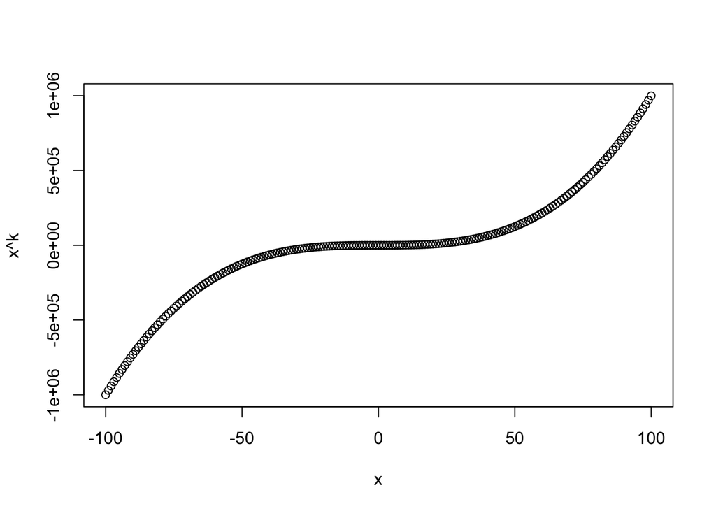

```
##   [1] -1000000  -970299  -941192  -912673  -884736  -857375  -830584  -804357
##   [9]  -778688  -753571  -729000  -704969  -681472  -658503  -636056  -614125
##  [17]  -592704  -571787  -551368  -531441  -512000  -493039  -474552  -456533
##  [25]  -438976  -421875  -405224  -389017  -373248  -357911  -343000  -328509
##  [33]  -314432  -300763  -287496  -274625  -262144  -250047  -238328  -226981
##  [41]  -216000  -205379  -195112  -185193  -175616  -166375  -157464  -148877
##  [49]  -140608  -132651  -125000  -117649  -110592  -103823   -97336   -91125
##  [57]   -85184   -79507   -74088   -68921   -64000   -59319   -54872   -50653
##  [65]   -46656   -42875   -39304   -35937   -32768   -29791   -27000   -24389
##  [73]   -21952   -19683   -17576   -15625   -13824   -12167   -10648    -9261
##  [81]    -8000    -6859    -5832    -4913    -4096    -3375    -2744    -2197
##  [89]    -1728    -1331    -1000     -729     -512     -343     -216     -125
##  [97]      -64      -27       -8       -1        0        1        8       27
## [105]       64      125      216      343      512      729     1000     1331
## [113]     1728     2197     2744     3375     4096     4913     5832     6859
## [121]     8000     9261    10648    12167    13824    15625    17576    19683
## [129]    21952    24389    27000    29791    32768    35937    39304    42875
## [137]    46656    50653    54872    59319    64000    68921    74088    79507
## [145]    85184    91125    97336   103823   110592   117649   125000   132651
## [153]   140608   148877   157464   166375   175616   185193   195112   205379
## [161]   216000   226981   238328   250047   262144   274625   287496   300763
## [169]   314432   328509   343000   357911   373248   389017   405224   421875
## [177]   438976   456533   474552   493039   512000   531441   551368   571787
## [185]   592704   614125   636056   658503   681472   704969   729000   753571
## [193]   778688   804357   830584   857375   884736   912673   941192   970299
## [201]  1000000
```

```r
my_func <- function(x, k){
    plot(x, x^k)
    x^k
}
my_func(-100:100, 3)
```

#### Exercise 2

Write and test a function that takes in input three arguments:

- x: a numeric vector
- k: an integer
- cols = c(c1, c2): a vector of two strings. c1 and c2 are colours. The default is c1=‘red’, c2=‘blue’

The function plots two lines (not points) in the same plot, $y_1 = x^k$ and $y_2 = x^{k+1}$. The colours of the two lines are set by the object `cols`. To solve this exercise, you need to carefully read the help page of the command `plot()`. Additional challenges:

- How do you set the default value of the object `cols`? You can use google to find it out.
- Can you take care of the title (main) on the graph? Hard code it in the plot command.
- Can you use different colours for the two lines?
- Can you insert a legend that explains which line is $y_1 = x^k$ and which one is $y_2 = x^{k+1}$? To solve this, you need to read the help page of the command `legend()`.
- Can you set the limits of the plots on the y-axis so that both functions are fully visualised?
- when testing the function, can you choose the values of the vector x such that the plot will look good?

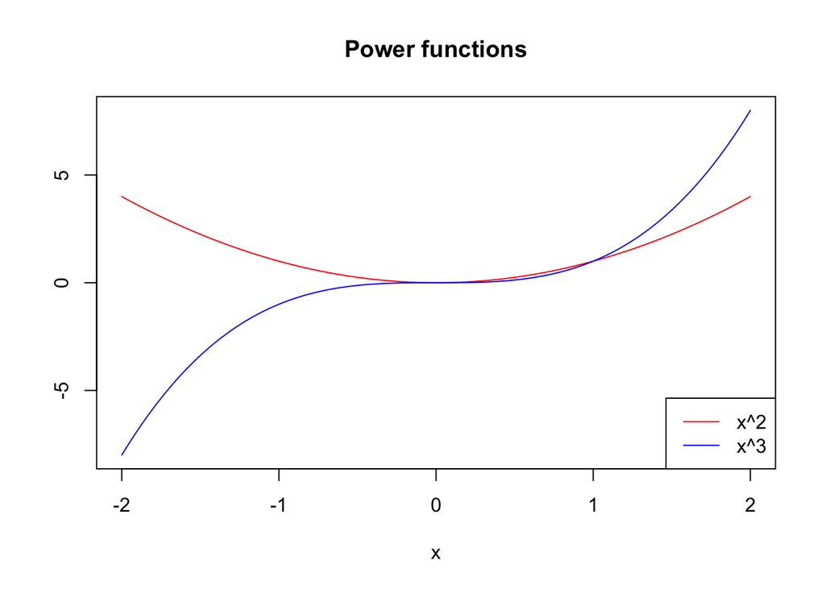

```r
my_func2 <- function(x, k, cols=c('red', 'blue')){
  f1=x^k
  f2=x^(k+1)
  ylim=range(c(f1,f2))
    plot(x, x^k, t='l', main="Power functions", col=cols[1], ylim=ylim, ylab='')
  lines(x, x^(k+1), col=cols[2])
  legend('bottomright',legend = c(paste("x^",k,sep=''), paste("x^",k+1,sep='')), col=cols, lty=1)
}
my_func2((-100:100)/50, 2)
```

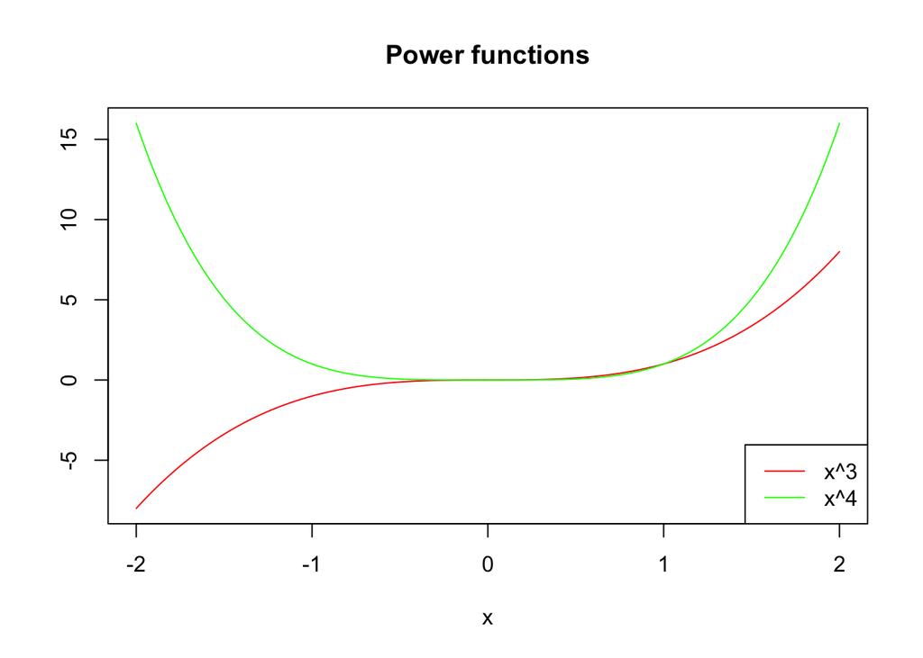

```r
my_func2((-100:100)/50, 3, cols = c('red', 'green'))
```

#### Exercise 3

In the last exercise for this week, you are going to write a generator of random numbers according to the following model:

$$y_i = \alpha + \beta_1 x_{1i} + \beta_2 x_{2i} + \epsilon_i$$
with $\epsilon_i \sim N(0, \sigma^2)$.

We can rewrite the model in matrix form as:

$$Y = \beta X + \epsilon$$
where $X$ is a matrix of 3 columns (vector of ones, $x_1$, $x_2$).

Write and test a function that takes in input the following arguments:

- N: integer, the number of observation to generate
- rx1: a numeric vector of length = 2, the range of $x_1$
- rx2: a numeric vector of length = 2, the range of $x_2$
- beta: a vector $(\alpha, \beta_1, \beta_2)$
- sigma: the standard deviation

and:

- generates the values of $Y$
- plots $x_1$ vs $Y$ and $x_2$ vs $Y$ in two distinct plots, using points. If you have time, you could look at the command `par(mfrow=c(1,2))` to display both plots in the same graph (or, in R lingo, in the same device).

In the function, an “elegant” solution is to use a matrix $X$ to generate $Y$. To do this, you should first generate the values of $x_1$ and $x_2$ in the given ranges rx1 and rx2 (e.g., using the function `seq()`, the function `runif()`, or both), and then create $X$, a matrix with N rows and 3 columns. The first column is a vector of N ones and accounts for the intercept (use the function `rep()`), while the second and third columns are $x_1$ and $x_2$.

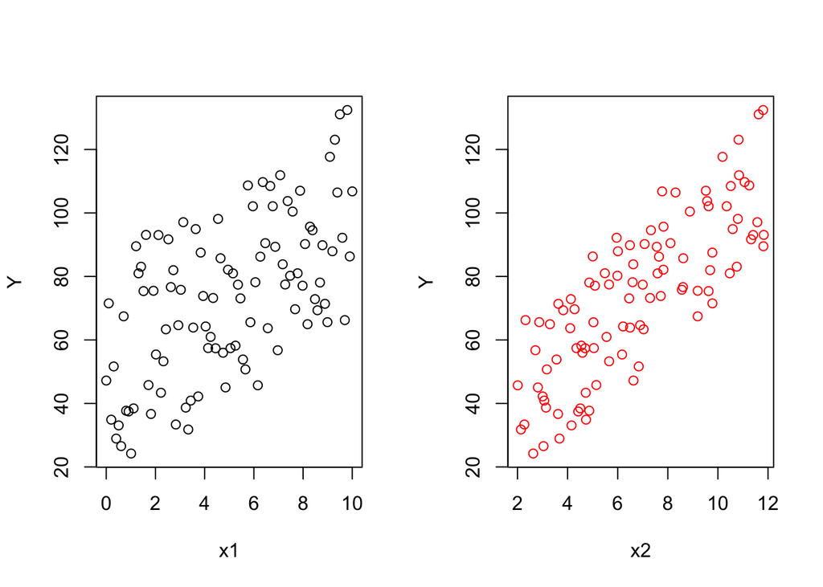

```r
my_gen_func <- function(N, rx1, rx2, beta, sigma){
  X = cbind(rep(1, N), seq(rx1[1], rx1[2], len=N), runif(N, min=rx2[1], max=rx2[2]))
  Y = t(beta %*% t(X)) + rnorm(N, 0, sigma)
  par(mfrow=c(1,2))
  plot(X[,2], Y, xlab="x1")
  plot(X[,3], Y, xlab="x2", col='red')
  par(mfrow=c(1,1))
}
my_gen_func(100, c(0,10), c(2,12), beta=c(1,5,7), sigma=1)
```